# Snowshoe Hares

Keene Morrow

February 6th, 2020

*Lepus americanus*, the snowshoe hare, is a species of hare found in the northern areas of North America. (Murray & Smith 2008) It is known for its change in coloration from brown in the summer to white in the winter and its long, snowshoe-like, hind feet. (Montana 2018) The population of snowshoe hares at Bonanza Creek Experimental Forest in interior Alaska was monitored using capture-recapture methods from 1999 to 2012. (Kielland, Chapin, & Ruess 2017)

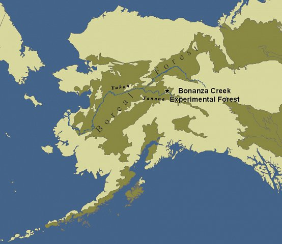

*Study site at Bonanza Creek, Alaska, Bonanza LTER, UAF*

#### Analysis & Results

```r
# Read in data
bunnies <- read_csv(here::here("data", "showshoe_lter.csv")) # yes, yes rabbits != hares
```

```r
# Prepare data
adults_all <- bunnies %>%
  mutate(date = lubridate::mdy(date)) %>% # dates to date class
  mutate(sex = str_to_upper(sex), # impose order on strings
         age = str_to_upper(age),
         month = month(date, label = TRUE), # create month variable
         year = year(date)) %>% # create year variable
  filter(sex %in% c("M", "F")) %>% # remove observations without definitive sex recorded
  drop_na(age, weight) %>% # remove observations without age or weight recorded
  filter(str_detect(age, pattern = "A")) %>% # filter for adults only
  mutate(age = "A") # wrangle age for consistency
```

```r
# Create data frame of only adult females
adults_f <- adults_all %>%
  filter(sex == "F")

# Create data frame of only adult males
adults_m <- adults_all %>%
  filter(sex == "M")
```

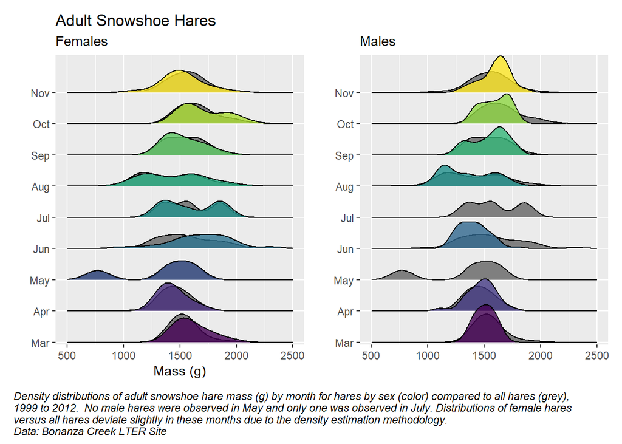

```r
# Visualize weight distribution
## Adult females versus all adults
ggplot() +
  # All adults
  geom_density_ridges(data = adults_all,
                      aes(x = weight, y = month),
                      fill = "grey50",
                      scale = 0.9) +
  # Adult females only
  geom_density_ridges(data = adults_f,
                      aes(x = weight, y = month, fill = month),
                      alpha = 0.8,
                      show.legend = FALSE,
                      scale = 0.9) +
  scale_y_discrete(expand = expand_scale(mult = c(0.01, 0.15))) +
  scale_x_continuous(limits = c(500, 2500)) +
  labs(title = "Adult Snowshoe Hares",
       subtitle = "Females",
       x = "Mass (g)",
       y = "") +
## Adult males versus all adults
ggplot() +
  # All adults
  geom_density_ridges(data = adults_all,
                      aes(x = weight, y = month),
                      fill = "grey50",
                      scale = 0.9) +
  # Adult males only
  geom_density_ridges(data = adults_m,
                      aes(x = weight, y = month, fill = month),
                      alpha = 0.8,
                      show.legend = FALSE,
                      scale = 0.9) +
  scale_y_discrete(expand = expand_scale(mult = c(0.01, 0.15))) +
  scale_x_continuous(limits = c(500, 2500)) +
  labs(subtitle = "Males",
       x = "",
       y = "") +
plot_annotation(caption = "Density distributions of adult snowshoe hare mass (g) by month for hares by sex (color) compared to all hares (grey),\n1999 to 2012.  No male hares were observed in May and only one was observed in July. Distributions of female hares\nversus all hares deviate slightly in these months due to the density estimation methodology.\nData: Bonanza Creek LTER Site",
                theme = theme(plot.caption = element_text(hjust = 0, face = "italic")))
```

```r
# Create data frame of observation counts by month, females, males, and total
adults_count <- adults_all %>%
  group_by(month, sex) %>%
  count(month) %>%
  pivot_wider(names_from = sex, values_from = n) %>%
  rename(Female = F,
         Male = M,
         Month = month) %>%
  mutate(Male = ifelse(is.na(Male), 0, Male),
         Total = Female + Male)

# Display count data frame as table
kable(adults_count) %>%
  kable_styling(bootstrap_options = "striped",
                full_width = F,
                position = "center"
                ) %>%
  add_header_above(c("Table 1. Adult Snowshoe Hare\nCounts by month, 1999 to 2012" = 4))
```

| Table 1. Adult Snowshoe Hare Counts by month, 1999 to 2012 Month | Table 1. Adult Snowshoe Hare Counts by month, 1999 to 2012 Female | Table 1. Adult Snowshoe Hare Counts by month, 1999 to 2012 Male | Table 1. Adult Snowshoe Hare Counts by month, 1999 to 2012 Total |
| --- | --- | --- | --- |
| Mar | 17 | 30 | 47 |
| Apr | 21 | 26 | 47 |
| May | 8 | 0 | 8 |
| Jun | 58 | 46 | 104 |
| Jul | 5 | 1 | 6 |
| Aug | 165 | 105 | 270 |
| Sep | 24 | 21 | 45 |
| Oct | 27 | 28 | 55 |
| Nov | 68 | 43 | 111 |

No observations were made between December and February in any year. Variation in monthly observations is likely due to survey frequency and conditions on the ground rather than actual abundance.

```r
# Create data frame of mean weights by month, females and males
adults_summary_sex <- adults_all %>%
  group_by(month, sex) %>%
  summarize(mean_weight = mean(weight)) %>%
  pivot_wider(names_from = sex, values_from = mean_weight) %>%
  rename(Female = F,
         Male = M)

# Create data frame of mean weights by month for all adults
adults_summary_all <- adults_all %>%
  group_by(month) %>%
  summarize(All = mean(weight))

# Combine data frames
adults_summary <- merge(adults_summary_sex, adults_summary_all)

# Display mean weight data frame as table
kable(adults_count) %>%
  kable_styling(bootstrap_options = "hover",
                full_width = F,
                position = "center"
                ) %>%
  add_header_above(c("Table 2. Adult Snowshoe Hare\nMean weights by month, 1999 to 2012" = 4))
```

[output not shown]

#### References

Bonanza Creek LTER. Institute of Arctic Biology, University of Alaska Fairbanks. http://www.lter.uaf.edu/

Gordon, D. & E. Robertson. 2013. Snowshoe Hare (Lepus americanus), white morph, Shirleys Bay, Ottawa, Ontario, Canada. https://commons.wikimedia.org/wiki/File:Snowshoe_Hare,_Shirleys_Bay.jpg

Kielland K., F. S. Chapin, R. W. Ruess. 2017. Snowshoe hare physical data in Bonanza Creek Experimental Forest: 1999-Present. Environmental Data Initiative. https://doi.org/10.6073/pasta/03dce4856d79b91557d8e6ce2cbcdc14.

Montana. 2018. Snowshoe Hare - *Lepus americanus*. Montana Field Guide. Montana Natural Heritage Program and Montana Fish, Wildlife and Parks. http://fieldguide.mt.gov/speciesDetail.aspx?elcode=AMAEB03010

Murray, D. & Smith, A.T. 2008. *Lepus americanus* . The IUCN Red List of Threatened Species 2008: e.T41273A10411354. https://dx.doi.org/10.2305/IUCN.UK.2008.RLTS.T41273A10411354.en.

National Park Service. 2004. Snowshoe Hare. http://www.nps.gov/noca/journey/images/for_car/hare_snowshoe.htm